# RC_analysis

Sara Perrins

2023-09-12

### Recovery Capital

Histogram shows non normal distribution

```r
final$RecoveryCapital <-NA
final$RecoveryCapital <- rowSums(final[ c("Q15_1","Q15_2","Q15_3","Q15_4","Q15_5","Q15_6","Q15_7","Q15_8","Q15_9","Q15_10","Q15_11")])

summary(final$RecoveryCapital)
```

```
##    Min. 1st Qu.  Median    Mean 3rd Qu.    Max.    NA's
##   11.00   39.00   46.00   41.82   52.00   55.00       2
```

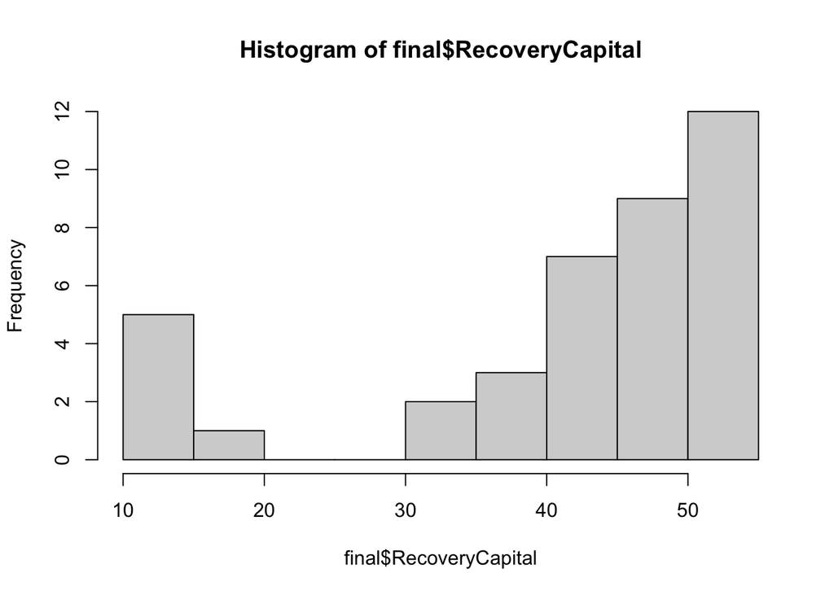

```r
hist(final$RecoveryCapital) #Shows non-normal distribution
```

### Results: Sample Characteristics- Treatment versus Control

**N = 22 Treatment; N = 18 Control**

```r
Results_SampleCharacteristics_TreatmentControl <- final %>%
  filter(Q5 !="") %>%
  group_by(TreatmentControl) %>%
  summarise(N = n())
print(Results_SampleCharacteristics_TreatmentControl)
```

```
## # A tibble: 2 × 2
##   TreatmentControl     N
##   <chr>            <int>
## 1 Control             18
## 2 Treatment           22
```

### Results: Sample Characteristics - N by grantee

```r
Results_SampleCharacteristics_grantee <- final %>%
  filter(Q5 !="") %>%
  group_by(TreatmentControl, Organization) %>%
  summarise(N = n())
print(Results_SampleCharacteristics_grantee)
```

```
## # A tibble: 7 × 3
## # Groups:   TreatmentControl [2]
##   TreatmentControl Organization                N
##   <chr>            <chr>                   <int>
## 1 Control          Above & Beyond - HHH       12
## 2 Control          Healing Action              2
## 3 Control          ServeMN                     4
## 4 Treatment        Above & Beyond - HHH        2
## 5 Treatment        Foundation for Recovery     2
## 6 Treatment        Healing Action              4
## 7 Treatment        ServeMN                    14
```

### Results: Sample Characteristics - Age

Table below shows n, percent, and mean of each age category by Treatment vs Control;  
Codebook: 1 17 or younger.  
2 18-29.  
3 30-39.  
4 40-49.  
5 50-59.  
6 60-69.  
7 70-79.  
8 80+.

```r
Results_SampleCharacteristics_Age <- final %>%
  filter(Q5!= "")  %>%
  group_by(TreatmentControl) %>%
  count(Q17) %>%
    mutate(prop = n / sum(n), mean = mean(n))

print(Results_SampleCharacteristics_Age)
```

```
## # A tibble: 10 × 5
## # Groups:   TreatmentControl [2]
##    TreatmentControl   Q17     n   prop  mean
##    <chr>            <int> <int>  <dbl> <dbl>
##  1 Control              3     5 0.278   4.5
##  2 Control              4     3 0.167   4.5
##  3 Control              5     7 0.389   4.5
##  4 Control              6     3 0.167   4.5
##  5 Treatment            1     2 0.0909  3.67
##  6 Treatment            2     4 0.182   3.67
##  7 Treatment            3     5 0.227   3.67
##  8 Treatment            4     8 0.364   3.67
##  9 Treatment            5     2 0.0909  3.67
## 10 Treatment            6     1 0.0455  3.67
```

### Results: Sample Characteristics - Sex

Table below shows n and percent of each sex category by Treatment vs Control;  
Codebook: 1 Male (including transgender);  
2 Female (including transgender);  
3 Non-binary/ non-conforming;  
4 Prefer to self describe (fill-in);  
5 Prefer not to say

```r
Results_SampleCharacteristics_Sex <- final %>%
  filter(Q5!= "")  %>%
  group_by(TreatmentControl) %>%
  count(QID17) %>%
    mutate(prop = n / sum(n))

print(Results_SampleCharacteristics_Sex)
```

```
## # A tibble: 10 × 4
## # Groups:   TreatmentControl [2]
##    TreatmentControl QID17     n   prop
##    <chr>            <int> <int>  <dbl>
##  1 Control              1     7 0.389
##  2 Control              2     6 0.333
##  3 Control              4     1 0.0556
##  4 Control              5     3 0.167
##  5 Control             NA     1 0.0556
##  6 Treatment            1     6 0.273
##  7 Treatment            2     7 0.318
##  8 Treatment            3     1 0.0455
##  9 Treatment            4     5 0.227
## 10 Treatment           NA     3 0.136
```

### Results: Sample Characteristics - Race

Table below shows n and percent of each race category by Treatment vs Control;  
Codebook: 1 White  
2 Black or African American  
3 American Indian or Alaska Native  
4 Asian or Pacific Islander  
5 Other (fill-in)  
6 Don’t know  
7 Prefer not to say.

```r
Results_SampleCharacteristics_Race <- final %>%
 filter(Q5!= "") %>%
  group_by(TreatmentControl) %>%
  count(Q21) %>%
    mutate(prop = n / sum(n))
print(Results_SampleCharacteristics_Race)
```

```
## # A tibble: 11 × 4
## # Groups:   TreatmentControl [2]
##    TreatmentControl Q21           n   prop
##    <chr>            <chr>     <int>  <dbl>
##  1 Control          "1"           8 0.444
##  2 Control          "1,2,3,5"     2 0.111
##  3 Control          "2"           4 0.222
##  4 Control          "5"           1 0.0556
##  5 Control          "7"           3 0.167
##  6 Treatment        ""            2 0.0909
##  7 Treatment        "1"          15 0.682
##  8 Treatment        "2"           2 0.0909
##  9 Treatment        "4"           1 0.0455
## 10 Treatment        "5"           1 0.0455
## 11 Treatment         <NA>         1 0.0455
```

### Results: Sample Characteristics - Ethnicity

Table below shows n and percent of each ethnicity category by Treatment vs Control;  
Codebook: “Are you of Hispanic, Latino/a, or Spanish origin?”  
1 Yes  
2 No. 3 Don’t know. 4 Prefer not to say

```r
Results_SampleCharacteristics_Ethnicity <- final %>%
 filter(Q5!= "") %>%
  group_by(TreatmentControl) %>%
  count(Q23) %>%
    mutate(prop = n / sum(n))
print(Results_SampleCharacteristics_Ethnicity)
```

```
## # A tibble: 6 × 4
## # Groups:   TreatmentControl [2]
##   TreatmentControl   Q23     n   prop
##   <chr>            <int> <int>  <dbl>
## 1 Control              1     3 0.167
## 2 Control              2    12 0.667
## 3 Control              3     2 0.111
## 4 Control              4     1 0.0556
## 5 Treatment            2    19 0.864
## 6 Treatment           NA     3 0.136
```

Treatment:  
86.3% NOT Hispanic, Latino/a, or Spanish origin

### Results: Sample Characteristics - Education

Codebook: “What is the highest grade or year of school you completed?”  
1 Never attended school or only kindergarten  
2 Elementary  
3 Some high school  
4 High school graduate or equivalent  
5 Some college or technical school  
6 College graduate  
7 Prefer not to say

```r
Results_SampleCharacteristics_Education <- final %>%
  filter(Q5!= "") %>%
  group_by(TreatmentControl) %>%
  count(Q25) %>%
    mutate(prop = n / sum(n))
print(Results_SampleCharacteristics_Education)
```

```
## # A tibble: 10 × 4
## # Groups:   TreatmentControl [2]
##    TreatmentControl   Q25     n   prop
##    <chr>            <int> <int>  <dbl>
##  1 Control              3     5 0.278
##  2 Control              4     1 0.0556
##  3 Control              5     8 0.444
##  4 Control              6     1 0.0556
##  5 Control              7     3 0.167
##  6 Treatment            3     1 0.0455
##  7 Treatment            4     6 0.273
##  8 Treatment            5     8 0.364
##  9 Treatment            6     4 0.182
## 10 Treatment           NA     3 0.136
```

### Reframing to count those with high school education or higher:

```r
Results_SampleCharacteristics_Education.MinimumHighSchool <- final %>%
  filter(Q5!= "")  %>%
  group_by(TreatmentControl) %>%
  count(Q25 > 3 & Q25 < 7) %>%
    mutate(prop = n / sum(n))
print(Results_SampleCharacteristics_Education.MinimumHighSchool)
```

```
## # A tibble: 5 × 4
## # Groups:   TreatmentControl [2]
##   TreatmentControl `Q25 > 3 & Q25 < 7`     n   prop
##   <chr>            <lgl>               <int>  <dbl>
## 1 Control          FALSE                   8 0.444
## 2 Control          TRUE                   10 0.556
## 3 Treatment        FALSE                   1 0.0455
## 4 Treatment        TRUE                   18 0.818
## 5 Treatment        NA                      3 0.136
```

### Results_Recovery Capital: mean, min, max and sd for entire treatment/control groups

Shows spread and center for outcome: Recovery Capital by treatment group:

```r
Results_SampleCharacteristics_RecoveryCapital <- final %>%
 filter(Q5!= "")  %>%
  group_by(TreatmentControl) %>%
  summarise(meanRecoveryCapital = mean(RecoveryCapital, na.rm = T), sdRecoveryCapital = sd(RecoveryCapital, na.rm = T), minRecoveryCapital = min(RecoveryCapital, na.rm = T), maxRecoveryCapital = max(RecoveryCapital, na.rm = T)) %>%
  ungroup()
print(Results_SampleCharacteristics_RecoveryCapital)
```

```
## # A tibble: 2 × 5
##   TreatmentControl meanRecoveryCapital sdRecoveryCapital minRecoveryCapital
##   <chr>                          <dbl>             <dbl>              <dbl>
## 1 Control                         38.9              15.3                 11
## 2 Treatment                       44.3              12.7                 11
## # ℹ 1 more variable: maxRecoveryCapital <dbl>
```

#### Results_Recovery Capital: Mean, Median and SD for each item by treatment group.

Results suggest the Treatment group have higher mean scores for each of the 11 items.  
Some median numbers are same across groups, but several are higher for the treatment group.

```r
Results_RecoveryCapital_Itemized <- final %>%
  filter(Q5!= "") %>%
  group_by(TreatmentControl) %>%
  summarise_at(.vars = names(.)[24:34],
               .funs = c(Median = "median", Mean = "mean", SD = "sd"), na.rm = T) %>%
  pivot_longer(cols = -TreatmentControl,names_to = "Item", values_to = "value")

print(Results_RecoveryCapital_Itemized)
```

```
## # A tibble: 66 × 3
##    TreatmentControl Item          value
##    <chr>            <chr>         <dbl>
##  1 Control          Q15_1_Median    5
##  2 Control          Q15_2_Median    4
##  3 Control          Q15_3_Median    4
##  4 Control          Q15_4_Median    3
##  5 Control          Q15_5_Median    3.5
##  6 Control          Q15_6_Median    4
##  7 Control          Q15_7_Median    4
##  8 Control          Q15_8_Median    4
##  9 Control          Q15_9_Median    4.5
## 10 Control          Q15_10_Median   4
## # ℹ 56 more rows
```

```r
write.csv(Results_RecoveryCapital_Itemized, "Results_RecoveryCapital_Itemized.csv")
```

```r
 RCitems <- c('Q15_1','Q15_2','Q15_3','Q15_4','Q15_5',
 'Q15_6','Q15_7','Q15_8','Q15_9','Q15_10','Q15_11')


 Results_RecoveryCapital_Count <- final %>%
    filter(Q5!= "") %>%
   pivot_longer(matches("Q15")) %>%
   group_by(TreatmentControl, name, value) %>%
   summarise(n = n(), .groups = 'drop') %>%
   pivot_wider(values_from = n)

 print(Results_RecoveryCapital_Count)
```

```
## # A tibble: 11 × 13
##    TreatmentControl value Q15_1 Q15_10 Q15_11 Q15_2 Q15_3 Q15_4 Q15_5 Q15_6
##    <chr>            <int> <int>  <int>  <int> <int> <int> <int> <int> <int>
##  1 Control              1     4      4      4     3     4     3     4     5
##  2 Control              4     3      5      4     8     8     4     7     5
##  3 Control              5    11      8      8     4     6     4     2     7
##  4 Control              3    NA      1      2     2    NA     5     1    NA
##  5 Control              2    NA     NA     NA     1    NA     2     4     1
##  6 Treatment            1     3      2      2     3     2     2     3     4
##  7 Treatment            4     1      9      4     8     6     5     5     7
##  8 Treatment            5    17      9     16     8    10    11     7     7
##  9 Treatment           NA     1     NA     NA    NA    NA    NA    NA    NA
## 10 Treatment            3    NA      2     NA     2     4     2     5     3
## 11 Treatment            2    NA     NA     NA     1    NA     2     2     1
## # ℹ 3 more variables: Q15_7 <int>, Q15_8 <int>, Q15_9 <int>
```

```r
 write.csv(Results_RecoveryCapital_Count, "Results_RecoveryCapital_Count.csv")

#Checking the counts are accurate:
 # final %>% select(starts_with('Q15'),TreatmentControl) %>% arrange(TreatmentControl)
```

#### Results_Recovery Capital: Mann-Whitney test results for TOTAL Recovery Capital

This non parametric test assess whether the treatment and control groups are identical in their total RC score (i.e., the sum of their responses to Q15_1:Q15_11) Results suggest that the treatment and control groups are NOT statistically different in their median scores.  
W = 146.5, p-value = 0.2354.

```r
test.RecoveryCapital <- wilcox.test(RecoveryCapital ~ TreatmentControl, data=final)
print(test.RecoveryCapital)
```

```
##
##  Wilcoxon rank sum test with continuity correction
##
## data:  RecoveryCapital by TreatmentControl
## W = 146.5, p-value = 0.2354
## alternative hypothesis: true location shift is not equal to 0
```

#### Results_Recovery Capital: Statistical Test for Differences for Each Item

Results suggest marginal significance (p = 0.073) for item 4;  
marginal significance (p = 0.072) for item 9;  
marginal significance (p = 0.057) for item 11.

```r
map_df(final[c(24:34)], ~ wilcox.test(.x ~ TreatmentControl, data = final, na.rm = TRUE, exact = FALSE)$p.value)
```

```
## # A tibble: 1 × 11
##   Q15_1 Q15_2 Q15_3  Q15_4 Q15_5 Q15_6 Q15_7 Q15_8  Q15_9 Q15_10 Q15_11
##   <dbl> <dbl> <dbl>  <dbl> <dbl> <dbl> <dbl> <dbl>  <dbl>  <dbl>  <dbl>
## 1 0.218 0.432 0.574 0.0731 0.225 0.932 0.293 0.323 0.0722  0.816 0.0572
```

#### Results_Use of Services

Codebook: “Since entering recovery, how often have you utilized physical and/or behavioral health services on average? - Selected Choice”

1 Daily. 2 Once per week or more  
3 One or two times a month  
4 A couple times a year  
5 Less than two times a year  
6 I do not attend health services  
7 Other (fill-in)

very similar means in use of Services across groups.

```r
Results_SampleCharacteristics_Services <- final %>%
  filter(Q5!="") %>%
  group_by(TreatmentControl) %>%
  summarise (meanServices = mean(Q13, na.rm = T), sdServices = sd(Q13, na.rm = T), minServices = min(Q13, na.rm = T), maxServices = max(Q13, na.rm = T)) %>%
  ungroup()
print(Results_SampleCharacteristics_Services)
```

```
## # A tibble: 2 × 5
##   TreatmentControl meanServices sdServices minServices maxServices
##   <chr>                   <dbl>      <dbl>       <int>       <int>
## 1 Control                  3          2.06           1           6
## 2 Treatment                3.10       2.51           1           7
```

#### Results_Services: Mann Whitney U Test

The two groups are not statistically different.  
W = 197.5, p= 0.815

```r
wilcox.test(Q13 ~ TreatmentControl, data = final, na.rm = TRUE, exact = FALSE)
```

```
##
##  Wilcoxon rank sum test with continuity correction
##
## data:  Q13 by TreatmentControl
## W = 197.5, p-value = 0.815
## alternative hypothesis: true location shift is not equal to 0
```

#### Results_Opioid Use

Codebook: “How often have you used opioids in the last 30 days?”  
1 Once or more times a day  
2 A few times per week. 3 A few times per month. 4 Once a month. 5 I have not used opioids in the last 30 days

very similar means in Opioid Use in last 30 days across groups.

```r
Results_SampleCharacteristics_OpioidUse <- final %>%
  filter(Q5!="") %>%
  group_by(TreatmentControl) %>%
  summarise (meanOpioidUse = mean(Q12, na.rm = T), sdOpioidUse = sd(Q12, na.rm = T), minOpioidUse = min(Q12, na.rm = T), maxOpioidUse = max(Q12, na.rm = T)) %>%
  ungroup()
print(Results_SampleCharacteristics_OpioidUse)
```

```
## # A tibble: 2 × 5
##   TreatmentControl meanOpioidUse sdOpioidUse minOpioidUse maxOpioidUse
##   <chr>                    <dbl>       <dbl>        <int>        <int>
## 1 Control                   4.53        1.33            1            5
## 2 Treatment                 4.4         1.47            1            5
```

#### Results_OpioidUse: Mann Whitney U Test

The two groups are not statistically different.  
W = 175.5, p= 0.797

Histogram shows we only had 1 (Once or more times a day), or 5 (never used in the past 30 days) as responses.

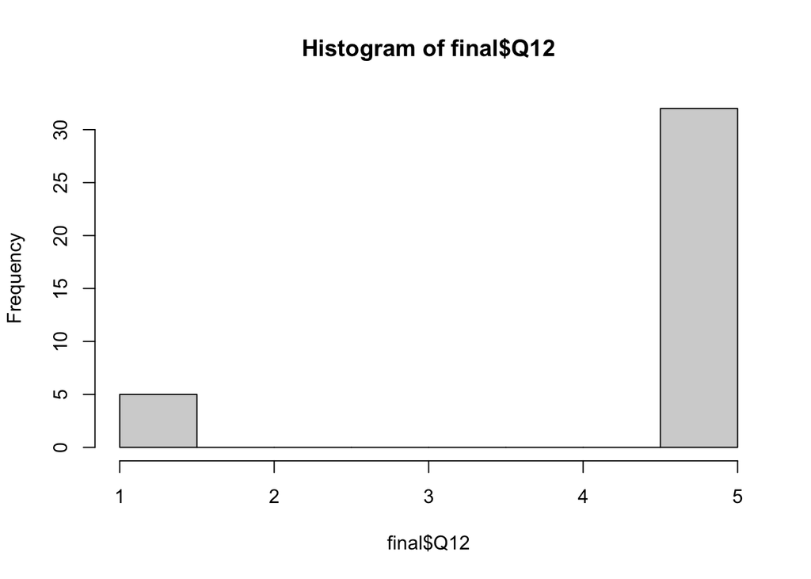

```r
hist(final$Q12)
```

```r
wilcox.test(Q12 ~ TreatmentControl, data = final, na.rm = TRUE, exact = FALSE)
```

```
##
##  Wilcoxon rank sum test with continuity correction
##
## data:  Q12 by TreatmentControl
## W = 175.5, p-value = 0.797
## alternative hypothesis: true location shift is not equal to 0
```